# Trump Fared Worst Than Romney with Florida Hispanics

2016-12-20 11:57:55

(cross posting from The Hill [blog post](http://thehill.com/blogs/pundits-blog/presidential-campaign/310760-study-finds-trump-faired-worse-than-romney-with))

The 2016 National Exit Poll, a proprietary survey conducted by Edison research, reports 29 percent of Hispanic voters nationwide supported president-elect Donald Trump, a two percentage-point increase over Mitt Romney’s 27 percent in the 2012 NEP.

We are not the first to argue that it seems implausible that Trump increased his Latino vote share despite his anti-immigrant rhetoric.

In contrast the Latino Decisions [election eve poll](http://www.latinovote2016.com/app/) reported Trump doing worse than Romney among Latinos, with a record low 18%.

Recently other social scientists have pointed out that official precinct data in [Texas](https://www.washingtonpost.com/news/monkey-cage/wp/2016/12/02/donald-trump-did-not-win-34-of-latino-vote-in-texas-he-won-much-less/) and [Arizona](http://www.azcentral.com/story/opinion/op-ed/2016/11/26/exit-polls-wrong-latino-voters-arizona/94288570/) both indicate that Trump received a record low Latino vote, and that exit poll data for Latinos seemed wrong.

Given the public availability of official precinct data, it is not difficult to extend this analysis to other states. Here we examine the Latino vote in the critical battleground state of Florida.

In addition to the exit poll numbers suggesting Trump won more Latino votes, pundits such as [Harry Enten](http://fivethirtyeight.com/features/trump-probably-did-better-with-latino-voters-than-romney-did/) and [Nate Cohn](http://www.nytimes.com/2016/11/15/upshot/how-did-trump-win-over-so-many-obama-voters.html?_r=0) have looked at county-level voting patterns and also agreed that Trump seemingly did better with Latinos than Romney.

However, counties are far too large of a unit to allow inferences to individual voters. Miami-Dade, for example, had around 975,000 votes cast.

Looking just at counties is misleading, and smaller levels such as voting precincts provide much greater precision when attempting to make individual inferences.

Consistently, [research](http://www.mattbarreto.com/papers/2004vote.pdf) has shown that exit polls under-samples voters who are more likely to support Democrats: those who live in majority-minority precincts, immigrants, non-college educated Latinos, and those who prefer to complete a survey in Spanish – all issues leading to bias in the results.

This is not a methodological point: if Trump can threaten to revoke birthright citizenship, establish a deportation force to round up and expel millions of immigrants and their families, and engage in racist accusations against an American-born judge on the basis of his parents’ ethnic heritage and still come away with more support than his predecessor did, why should either of the parties make positive appeals to the Hispanic community?

Here we look more closely at Florida, and demonstrate that even among the most conservative segment of the Hispanic community—Cubans in Miami-Dade—Trump did worse than Romney and Clinton did better than Obama.

Moreover, at the statewide level, our precinct-level estimates of Hispanic support look significantly worse for Trump than do the exit poll results.

We use this evidence to argue for renewed commitments to the Latino community and its policy preferences.

In at least one key respect, Florida’s Hispanic community is significantly different than nationally: 29 percent of Hispanic Floridians are Cuban, and they’ve voted for Republicans, historically.

This is due, in part, to their greater economic resources, privileged asylum status and historical patterns of support for Republicans fighting against Castro’s communism.

Still, the Cuban-American community is undergoing [change](http://www.pewresearch.org/fact-tank/2014/06/24/after-decades-of-gop-support-cubans-shifting-toward-the-democratic-party/). Younger U.S. born Cubans are less likely to cast a party-line vote for Republicans and some older Cuban immigrants are [less convinced](http://www.theatlantic.com/politics/archive/2016/03/changing-their-minds-on-cuba/474612/) an isolationist-only approach to the island is worthwhile amid the opening of relations with Cuba during the Obama years.

So what was the real Latino vote in 2016, and did Trump best Romney among Florida Hispanics? To answer this question, we turned to official vote tallies reported in 3,216 individual precincts in Florida, the smallest geographic unit reporting vote results that are available.

Our approach is superior to county-level analysis because we have many more data points available for analysis and because we make fewer assumptions about their demographic composition.

Counties are large and heterogeneous, and even the most heavily Hispanic counties contain sizeable non-Hispanic populations that limit inferences one can make about Hispanic voting behavior.

By contrast, precincts allow us to identify much smaller units that are greater than 95 percent Hispanic and compare them to precincts which are 50 percent or 10 percent Hispanic, which brings us much closer to identifying the voting preferences of individual Hispanics.

The method is based on aggregate data, a tricky endeavor that we accomplish through [ecological inference](http://gking.harvard.edu/category/research-interests/methods/ecological-inference), a technique developed by Harvard researchers.

Note that our argument is not merely one about Hispanic voting in heavily Hispanic precincts: our data in Florida contain all available precincts for 15 counties, with large and small Hispanic populations.

In the interest of transparency, we have posted all data to this [website](https://github.com/tylerreny/election2016) (my github page) for replication.

# Trends: 2012-2016

We used two approaches to answer the question of whether Clinton underperformed Obama in 2012 as Enten and Cohn have suggested. For each precinct in Florida we first took the net raw vote margin for Clinton in 2016 (i.e., Clinton votes – Trump votes) and subtracted from it the net raw vote margin for Obama in 2012 (i.e. Obama votes – Romney votes) – a similar approach taken by social scientists in their analysis of Texas precincts.

We then plotted the results by the percentage of all voters who are Latino in each precinct along the x-axis as shown in Figure 1. The data show that the larger the Latino population in a precinct, the more the mass of red dots shrinks while the mass of blue dots grows and gets darker.

In other words, for precincts that are 75 percent or more Latino, Clinton won more net votes than Obama in 88 percent of them.

In only 12 percent of Latino precincts did Clinton “run behind” Obama. Already this basic precinct data suggest Clinton outperformed Obama among Florida’s Hispanic population.

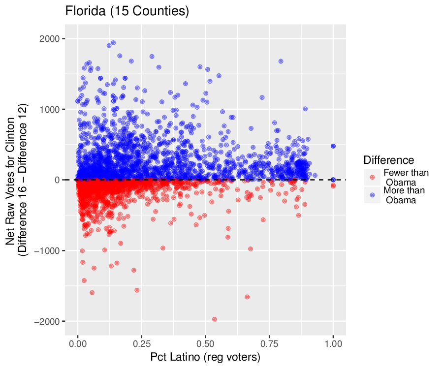